# Power analyses and simulations in R

Andrew Jessop

## Goal

- To run your own power analyses in R
- To understand why more data is better

## How

- Look at a range of different scenarios where power analysis is helpful
- Using the pwr, simr, and tidyverse packages in R

## https://github.com/andrew-jessop/imprs-power-analysis-workshop.git

## What is power?

- The probability of finding an effect statistically different from 0, if there is a true effect to be found
- Power analysis is often used to determine the number of subjects we need to test to have reasonable chance (80%) of observing our hypothesised effect

## Scenario 1

- You are designing a study investigating whether vocabulary size at 18 months correlates with concurrent lexical processing efficiency
- The smallest relationship that you would consider theoretically interesting is a Pearson’s r of 0.3 (medium effect; Cohen, 1992)
- You will reject the null hypothesis when p < .05 (alpha level) in a two-sided test
- **How many subjects (data points) do you need to have an 80% chance of observing this relationship?**

## Scenario 2

- A new meta-analysis has been published suggesting that the average correlation between vocabulary and reaction times is 0.2 (a small to medium effect; Cohen, 1992)
- On this basis, you now want to ensure that you have enough data to observe an correlation of at least 0.2
- You will reject the null hypothesis when p < .05 (alpha level) in a two-sided test
- **How many subjects do you need to have an 80% chance of observing this relationship?**

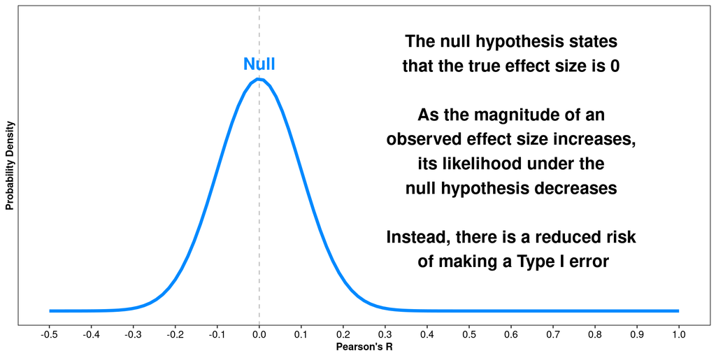

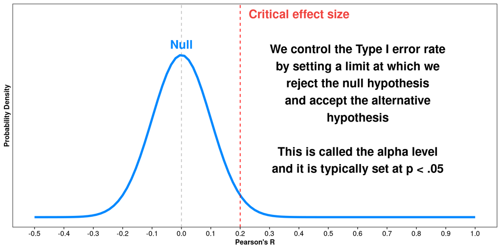

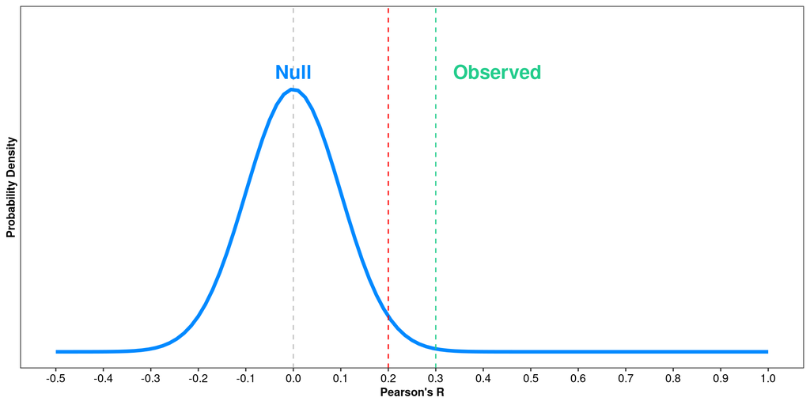

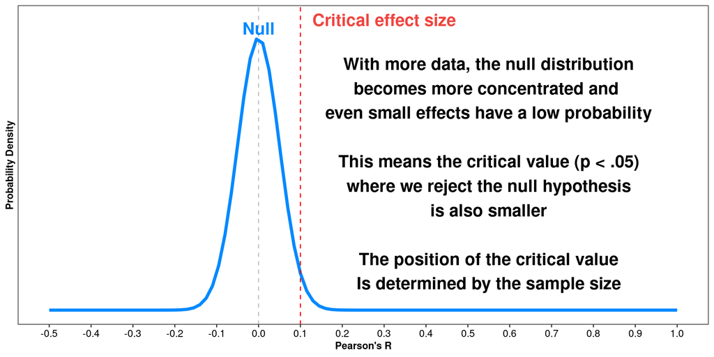

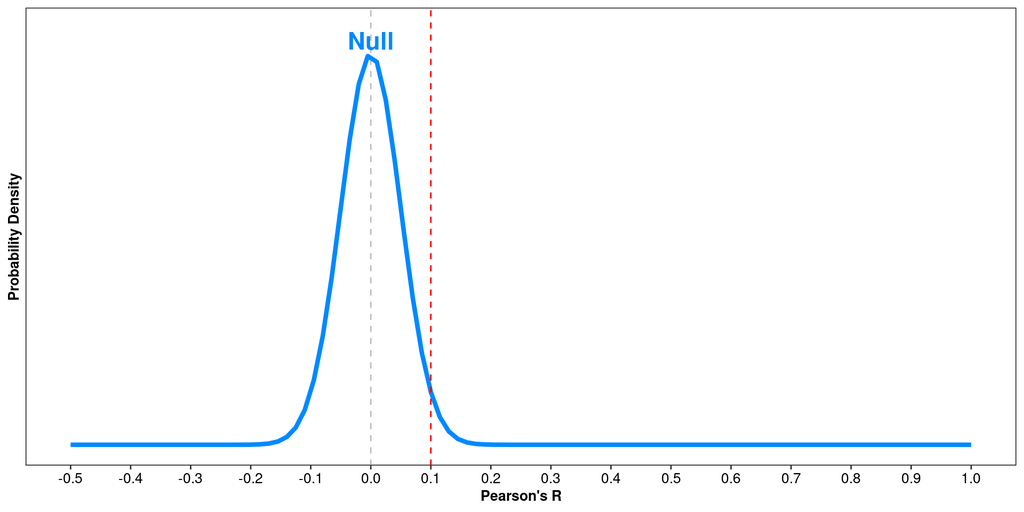

## Power analysis

- Power analyses allow us design our study so that we have enough data so that our critical value is smaller than the effect we expect to observe
- With enough data, you can plan a study to detect even very small relationships or effects

## Can you overpower a study?

- It is possible to continously collect data until you reach significance (*p* < .05)
- This is p-hacking (or data-dredging)
- We should focus on the effect size
- A reliable correlation where r = 0.01 (and *p* < .05) may not be very interesting

## Can you overpower a study?

- No! No! No!
- This is a weakness of the NHST approach
- What matters is how you interpret the effects
- More data offers more reliable effect size estimates
- More sophisticated analyses

## Scenario 3

- You have conducted a study that did not find a significant relationship (between vocabulary and reaction times)
- One reviewer is concerned about this null finding and suggests that your experiment is underpowered
- You collected 200 participants and observed a Pearson’s r of 0.13
- You decided that you would reject the null hypothesis when p < .05 (two-sided)
- The smallest effect you would consider theoretically interesting is 0.2
- **Is this study underpowered?**

## Observed power is flawed

- See Hoenig and Heisey (2001)
- Observed p-value also determines the observed power (1:1 function)
- Observed effect $\neq$ true effect
- true power depends on an unknown true effect size
- Confidence intervals, equivalences tests, and Bayes factors

## Calculate power based on…

1. Previous observations - meta-analyses or similar studies with *large* sample sizes
2. The smallest effect size that would be theoretically interesting

## Scenario 4

- You are planning a new and innovative individual differences study
- There is very little previous evidence, but you have decided that a Pearson’s r of 0.25 is the smallest relationship you would consider theoretically interesting
- Since this is a new area of enquiry, you have decided that an alpha level of .05 is not small enough to reject the null hypothesis

## What is the p-value?

- The probability of obtaining test results at least as extreme as those observed, assuming that the null hypothesis is correct
- We reject the null once p falls below the *alpha level*, which is what we consider an acceptable Type I error rate
- Type I error = rejecting the null hypothesis when it is true
- A false positive

## Modern approaches

- p < .05 is convenient but arbitrary
- p < .005 for new discoveries (Benjamin et al., 2018)
- Justify specific alpha levels (Lakens et al., 2018)
- Abandon significance and treat p as continous (McShane et al., 2019)

## Scenario 4

- You are planning a new and innovative individual differences study
- There is very little previous evidence, but you have decided that a Pearson’s r of 0.25 is the smallest relationship you would consider theoretically interesting
- Since this is a new area of enquiry, you have decided that an alpha level of .05 is not small enough to reject the null hypothesis
- You have decided to use an alpha level of .001 (1/1000)
- **How many subjects do you need to collect to reach 80% power**

## Scenario 5

- Since this is a new area of research, you want make sure that you’re not making a Type II error
- You have decided you want a 95% chance observing the hypothesised relationship (r = 0.25), if it exists

## What is power?

- Type II error = failing to reject the null when it is false
- False negative
- Beta level = the probability of a Type II error

## What is power?

- Power = 1 - $\beta$
- The probability of avoiding a Type II error
- The power to detect a *true* effect when it exists
- 80% is consider the minimum acceptable level

## Scenario 5

- Since this is new area of research, you want make sure that you’re not making a Type II error
- You have decided you want a 95% chance observing the hypothesised relationship (r = 0.25), if it exists
- **How many subjects do you need for 95% power**

## Scenario 6

- You have realised that your hypothesis is directional - you are predicting a positive correlation
- You switch to a one-tailed test instead of a two-tailed test
- **How many subjects do you need for 95% power**

## Two-tailed

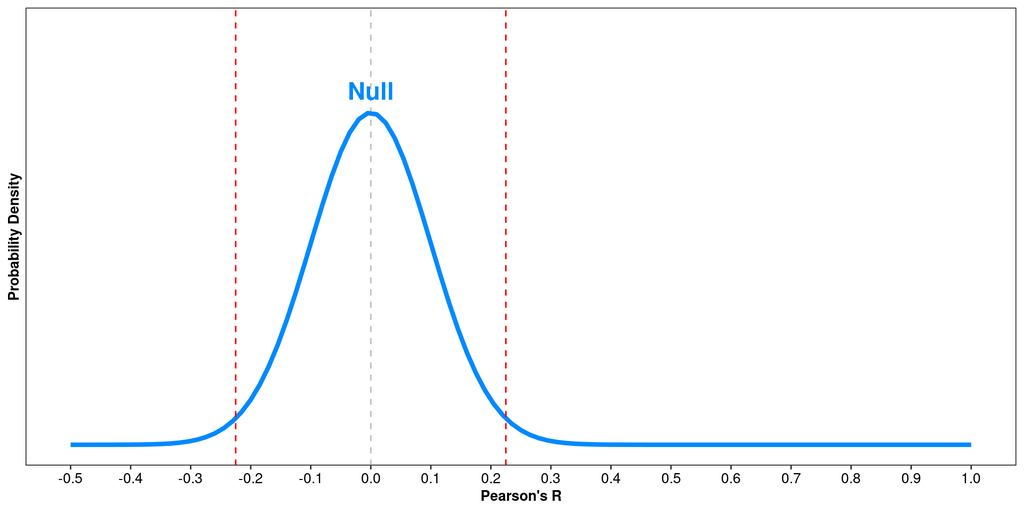

## One-tailed

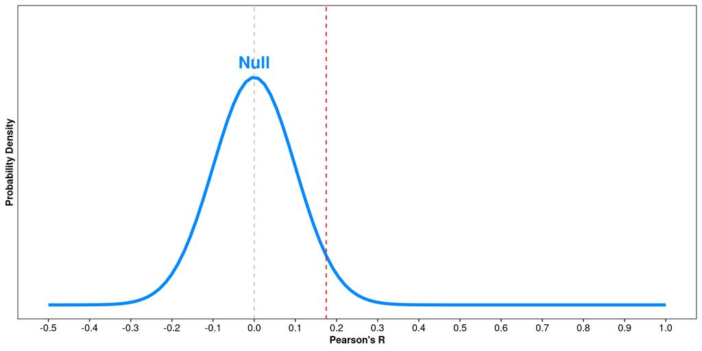

## Four critical parameters

1. The effect size of interest
2. The sample size
3. The power level
4. The alpha level

## BREAK

## Psychology is underpowered

- Cohen (1962): “…nonrational bases for setting sample size must often result in investigations being undertaken which have little chance of success despite the actual falsity of the null hypothesis”
- Things have not improved much since then (Button et al., 2013; Smaldino & McElreath, 2016)
- Less than 40% power seems typical of our field

## Conclusions

- The typical sample sizes used in psycholinguistic research are not enough
- Especially true now that we are using more mixed-effects models, which carry a power cost (Matuschek et al., 2017)
- We should aim to have the largest sample sizes

## Take home message

- Calculate your power levels **before** data collection
- Focus on **effect sizes** not p-values
- **More data is always better**